# Data Science for Business - Week 08: Kaggle Competition on Prediction of Elecricity Consumption

Oliver Mueller

# Initialize notebook

Load required packages.

```r
library(tidyverse)
library(lubridate)
library(ggthemr)
library(tidymodels)
library(naniar)
```

Set up workspace, i.e., remove all existing data from working memory, initialize the random number generator, turn of scientific notation of large numbers, set a standard theme for plotting. Finally, we activate parallel processing on multiple CPU cores.

```r
knitr::opts_chunk$set(echo = TRUE, warning = FALSE)
rm(list=ls())
set.seed(42)
options(scipen=10000)
ggthemr('fresh')
doParallel::registerDoParallel(cores = 3)
```

# Problem description

In this Kaggle competition, you will develop accurate models of metered building electricity usage in the following areas. The data comes from 100 buildings over a one-year time period.

# Load data

Load data from CSV files.

```r
train <- read_csv("train.csv")
test <- read_csv("test.csv")
```

# Explore Data

Analyze data quality (esp. missing values).

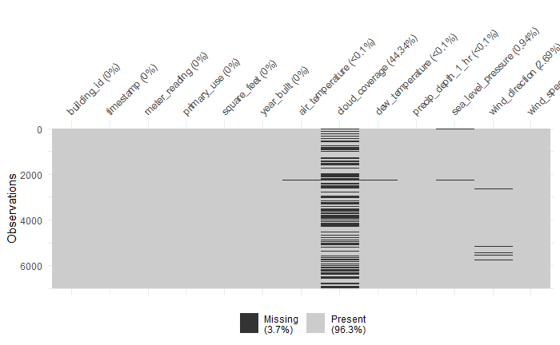

```r
vis_miss(sample_frac(train, 0.01))
```

# Modeling

## Model

Create a `model` specification for a LASSO model with a tunable `penalty` hyperparameter .

```r
electricity_mod_01 <- linear_reg(penalty = tune(), mixture = 1) %>%
  set_engine("glmnet")

electricity_mod_01
```

```
Linear Regression Model Specification (regression)

Main Arguments:
  penalty = tune()
  mixture = 1

Computational engine: glmnet
```

## Recipe

Next, we specify a `recipe` for data preprocessing and feature engineering.

```r
electricity_recipe <-
  recipe(meter_reading ~ ., data = train) %>%
  step_naomit()%>%
  step_mutate(
    month = as.factor(lubridate::month(timestamp)),
    dow = as.factor(lubridate::wday(timestamp)),
    dom = as.factor(lubridate::day(timestamp)),
    hour = as.factor(lubridate::hour(timestamp)) # extract hour of the day
  ) %>%
  step_rm(timestamp, cloud_coverage) %>%
  step_medianimpute(all_numeric()) %>%
  step_modeimpute(all_nominal()) %>%
  step_normalize(all_numeric(), -all_outcomes()) %>%
  step_dummy(all_nominal(), -all_outcomes())
```

[output not shown]

`Bake` the recipe, just the check whether it produces the expected results.

```r
tmp <- electricity_recipe %>%
  prep() %>%
  bake(head(train))

names(tmp)
```

```
 [1] "building_id"
 [2] "square_feet"
 [3] "year_built"
 [4] "air_temperature"
 [5] "dew_temperature"
 [6] "precip_depth_1_hr"
 [7] "sea_level_pressure"
 [8] "wind_direction"
 [9] "wind_speed"
[10] "meter_reading"
[11] "primary_use_Entertainment.public.assembly"
[12] "primary_use_Lodging.residential"
[13] "primary_use_Office"
[14] "primary_use_Other"
[15] "primary_use_Parking"
```

[output cut: 71 more lines]

## Workflow

The final specification is for the `workflow`, which glues together the `model` and `recipe`.

```r
electricity_wflow <- workflow() %>%
  add_model(electricity_mod_01) %>%
  add_recipe(electricity_recipe)

electricity_wflow
```

[output not shown]